# Red Wine Exploration by Tim Tse

Tim Tse

Saturday, May 16th, 2015

# Introduction

In this report, we have 11 input variables and 1 output variable. The goal of the assignment is to use Data analysis tools in R to identify which chemical properties influence the quality of red wines.

# Dataset Structure

The data-set we used contains 1,599 red wines samples and at least 3 wine experts rated the quality of each wine. Quality rating is between 0 (very bad)and 10 (very excellent).

Input variables (based on physicochemical tests):

1 - fixed acidity (tartaric acid - g / dm^3)

2 - volatile acidity (acetic acid - g / dm^3)

3 - citric acid (g / dm^3)

4 - residual sugar (g / dm^3)

5 - chlorides (sodium chloride - g / dm^3)

6 - free sulfur dioxide (mg / dm^3)

7 - total sulfur dioxide (mg / dm^3)

8 - density (g / cm^3)

9 - pH

10 - sulphates (potassium sulfate - g / dm^3)

11 - alcohol (% by volume)

Output variable (based on sensory data):

12 - quality (score between 0 and 10)

# What is the main feature of interest in your dataset?

The main interest is to find out what chemical properties have the most positive and negative influence on the red wine quality. From red wine experts, a good quality red wine is one that has a good balance of all chemical. However, we would like to investigate this data-set and observe how the chemicals in the red wine data-set samples actually affected the quality rating.

# Dataset Summary

### Names in Wine

```
##  [1] "X"                    "fixed.acidity"        "volatile.acidity"
##  [4] "citric.acid"          "residual.sugar"       "chlorides"
##  [7] "free.sulfur.dioxide"  "total.sulfur.dioxide" "density"
## [10] "pH"                   "sulphates"            "alcohol"
## [13] "quality"
```

### Dimension of the data-set

```
## [1] 1599   13
```

### Summary of the data-set

```
##        X          fixed.acidity   volatile.acidity  citric.acid
##  Min.   :   1.0   Min.   : 4.60   Min.   :0.1200   Min.   :0.000
##  1st Qu.: 400.5   1st Qu.: 7.10   1st Qu.:0.3900   1st Qu.:0.090
##  Median : 800.0   Median : 7.90   Median :0.5200   Median :0.260
##  Mean   : 800.0   Mean   : 8.32   Mean   :0.5278   Mean   :0.271
##  3rd Qu.:1199.5   3rd Qu.: 9.20   3rd Qu.:0.6400   3rd Qu.:0.420
##  Max.   :1599.0   Max.   :15.90   Max.   :1.5800   Max.   :1.000
##  residual.sugar     chlorides       free.sulfur.dioxide
##  Min.   : 0.900   Min.   :0.01200   Min.   : 1.00
##  1st Qu.: 1.900   1st Qu.:0.07000   1st Qu.: 7.00
##  Median : 2.200   Median :0.07900   Median :14.00
##  Mean   : 2.539   Mean   :0.08747   Mean   :15.87
##  3rd Qu.: 2.600   3rd Qu.:0.09000   3rd Qu.:21.00
##  Max.   :15.500   Max.   :0.61100   Max.   :72.00
##  total.sulfur.dioxide    density             pH          sulphates
##  Min.   :  6.00       Min.   :0.9901   Min.   :2.740   Min.   :0.3300
##  1st Qu.: 22.00       1st Qu.:0.9956   1st Qu.:3.210   1st Qu.:0.5500
##  Median : 38.00       Median :0.9968   Median :3.310   Median :0.6200
##  Mean   : 46.47       Mean   :0.9967   Mean   :3.311   Mean   :0.6581
##  3rd Qu.: 62.00       3rd Qu.:0.9978   3rd Qu.:3.400   3rd Qu.:0.7300
##  Max.   :289.00       Max.   :1.0037   Max.   :4.010   Max.   :2.0000
##     alcohol         quality
##  Min.   : 8.40   Min.   :3.000
##  1st Qu.: 9.50   1st Qu.:5.000
##  Median :10.20   Median :6.000
##  Mean   :10.42   Mean   :5.636
##  3rd Qu.:11.10   3rd Qu.:6.000
##  Max.   :14.90   Max.   :8.000
```

### Observations from dataset

- Quality is range from 3 to 8. Median is 6 with a mean of 5.636.
- Total sulfur dioxide and free sulfur dioxide has a very big range in the data-set.
- Alcohol level is range from 8.4% to 14.9% with a 10.2% median.
- pH value has a very small range. From 2.740 to 4.01, median and mean are both 3.31.
- Residual sugar also has a big range from 0.9 g/dm^3 to 15.5 g/dm^3.

### Key parameters distribution

(Fixed Acidity, Volatile Acidity, Citric Acid, Residual Sugar, Chlorides, Free SO2, Total SO2, Density, pH, Sulfates, Alcohol, and Quality)

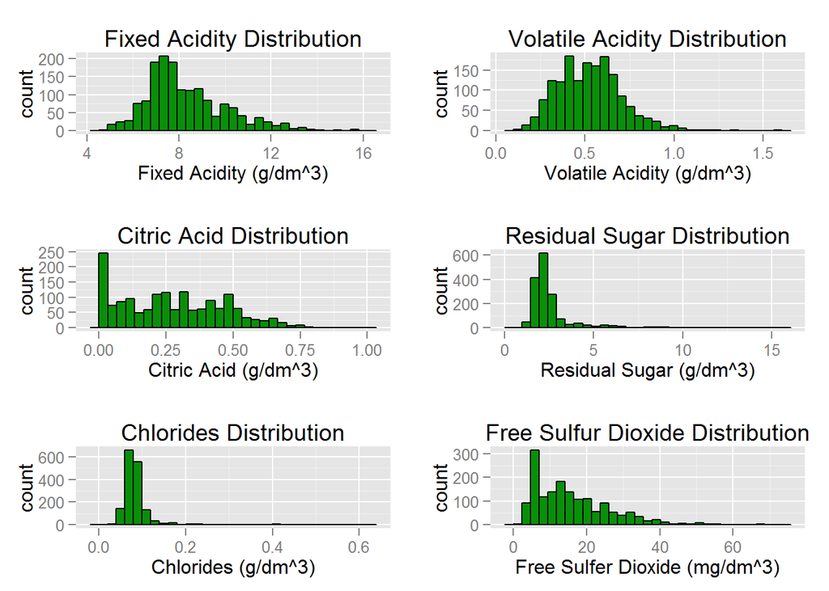

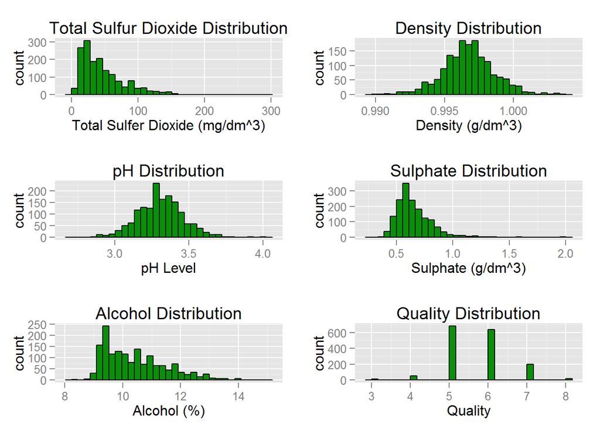

# Scatter-plot matrices

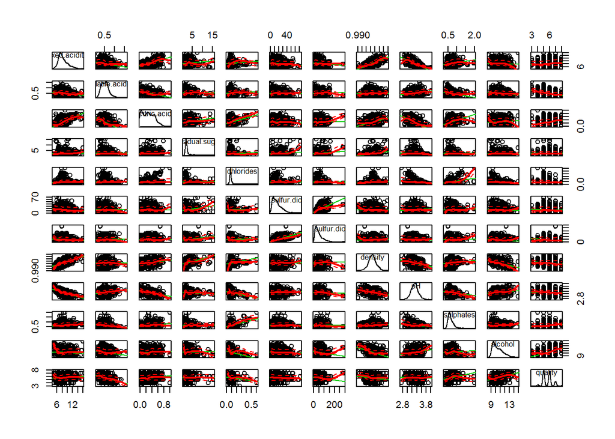

- From the Scatter-plot Matrices , we can see visually how each of the input variable has an effect on the quality of the wine. One of the most obvious observation is a negative relationship between volatile acidity to quality. On the other hand, alcohol level has a positive relationship with quality. The other input variables seems to be flat with small relationship with quality.

# Identifying Correlation with Quality

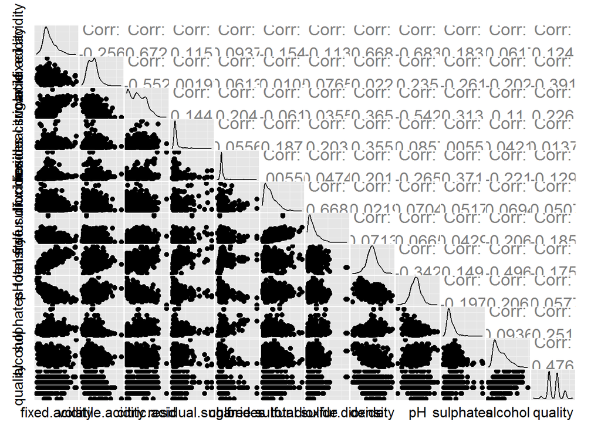

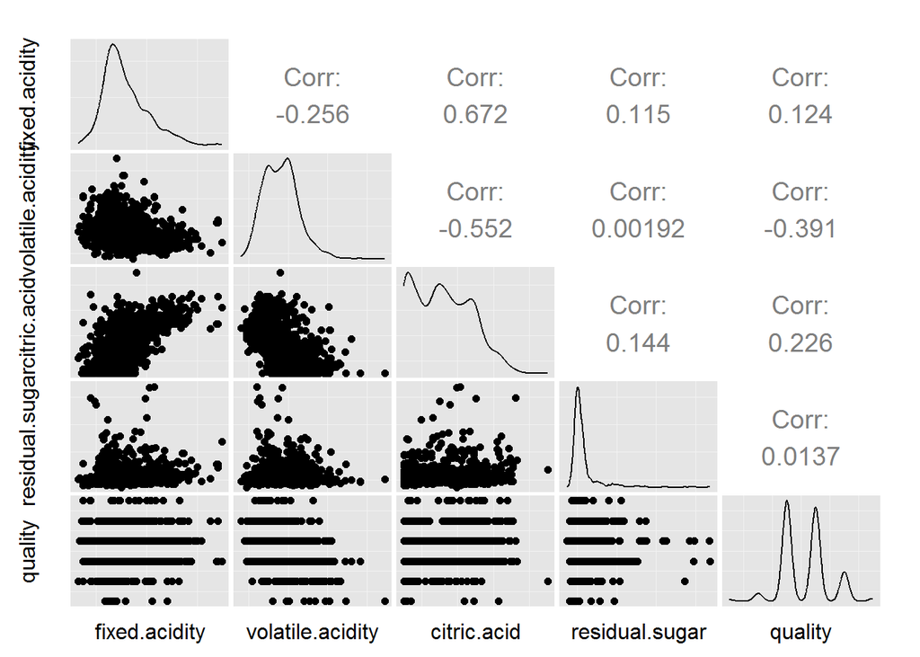

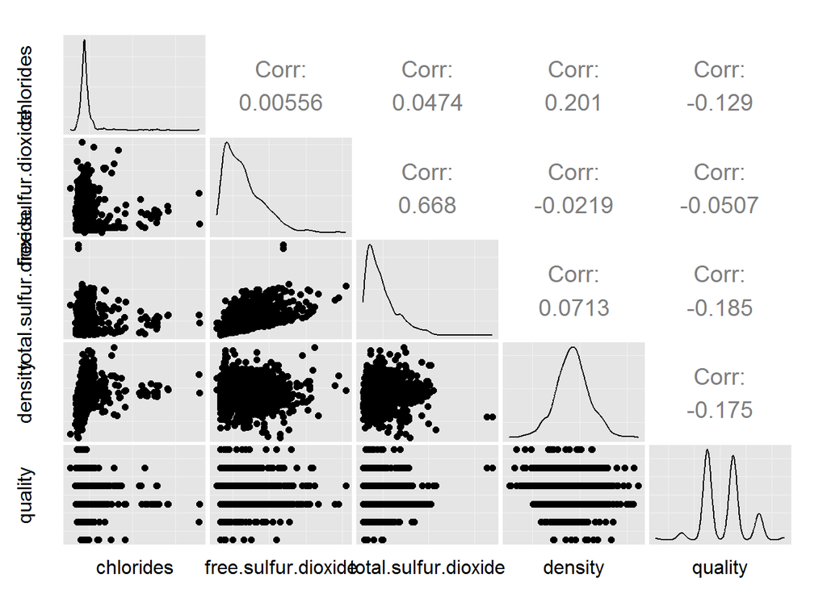

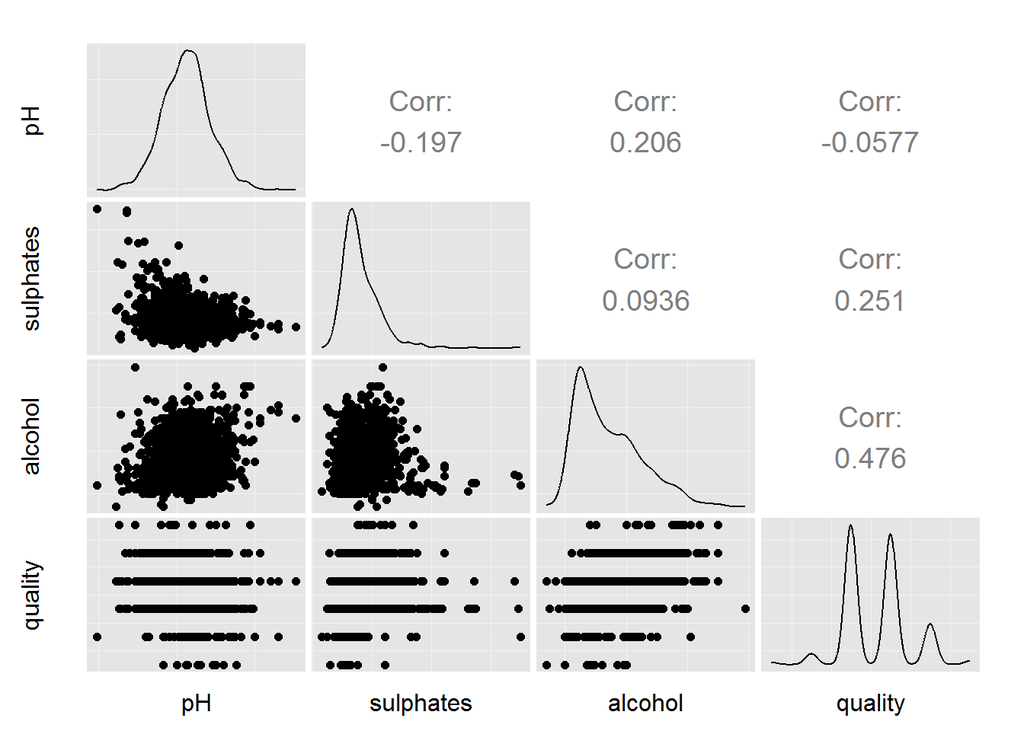

- From the ggpair plots, we can see the correlation between each input variables in pairing with quality. I break down the first plot into three different smaller ggpair plots to get a clearer comparison. In this exercise, we can confirm that volatile acidity has a strong negative correlation of -0.391 to quality, and alcohol level has a strong positive correlation of .476 to quality. Since alcohol and volatile acidity have a strong effect on the quality. Also, we see a strong correlation between fixed acidity and pH. We can focus on these two areas and do further analysis for our final plots.

### Correlation Values

```
##
## CORRELATIONS
## ============
## - correlation type:  pearson
## - correlations shown only when both variables are numeric
##
##                           X fixed.acidity volatile.acidity citric.acid
## X                         .        -0.268           -0.009      -0.154
## fixed.acidity        -0.268             .           -0.256       0.672
## volatile.acidity     -0.009        -0.256                .      -0.552
## citric.acid          -0.154         0.672           -0.552           .
## residual.sugar       -0.031         0.115            0.002       0.144
## chlorides            -0.120         0.094            0.061       0.204
## free.sulfur.dioxide   0.090        -0.154           -0.011      -0.061
## total.sulfur.dioxide -0.118        -0.113            0.076       0.036
## density              -0.368         0.668            0.022       0.365
## pH                    0.136        -0.683            0.235      -0.542
## sulphates            -0.125         0.183           -0.261       0.313
## alcohol               0.245        -0.062           -0.202       0.110
## quality               0.066         0.124           -0.391       0.226
##                      residual.sugar chlorides free.sulfur.dioxide
## X                            -0.031    -0.120               0.090
## fixed.acidity                 0.115     0.094              -0.154
## volatile.acidity              0.002     0.061              -0.011
## citric.acid                   0.144     0.204              -0.061
## residual.sugar                    .     0.056               0.187
## chlorides                     0.056         .               0.006
## free.sulfur.dioxide           0.187     0.006                   .
## total.sulfur.dioxide          0.203     0.047               0.668
## density                       0.355     0.201              -0.022
## pH                           -0.086    -0.265               0.070
## sulphates                     0.006     0.371               0.052
## alcohol                       0.042    -0.221              -0.069
## quality                       0.014    -0.129              -0.051
##                      total.sulfur.dioxide density     pH sulphates alcohol
## X                                  -0.118  -0.368  0.136    -0.125   0.245
## fixed.acidity                      -0.113   0.668 -0.683     0.183  -0.062
## volatile.acidity                    0.076   0.022  0.235    -0.261  -0.202
## citric.acid                         0.036   0.365 -0.542     0.313   0.110
## residual.sugar                      0.203   0.355 -0.086     0.006   0.042
## chlorides                           0.047   0.201 -0.265     0.371  -0.221
## free.sulfur.dioxide                 0.668  -0.022  0.070     0.052  -0.069
## total.sulfur.dioxide                    .   0.071 -0.066     0.043  -0.206
## density                             0.071       . -0.342     0.149  -0.496
## pH                                 -0.066  -0.342      .    -0.197   0.206
## sulphates                           0.043   0.149 -0.197         .   0.094
## alcohol                            -0.206  -0.496  0.206     0.094       .
## quality                            -0.185  -0.175 -0.058     0.251   0.476
##                      quality
## X                      0.066
## fixed.acidity          0.124
## volatile.acidity      -0.391
## citric.acid            0.226
## residual.sugar         0.014
## chlorides             -0.129
## free.sulfur.dioxide   -0.051
## total.sulfur.dioxide  -0.185
## density               -0.175
## pH                    -0.058
## sulphates              0.251
## alcohol                0.476
## quality                    .
```

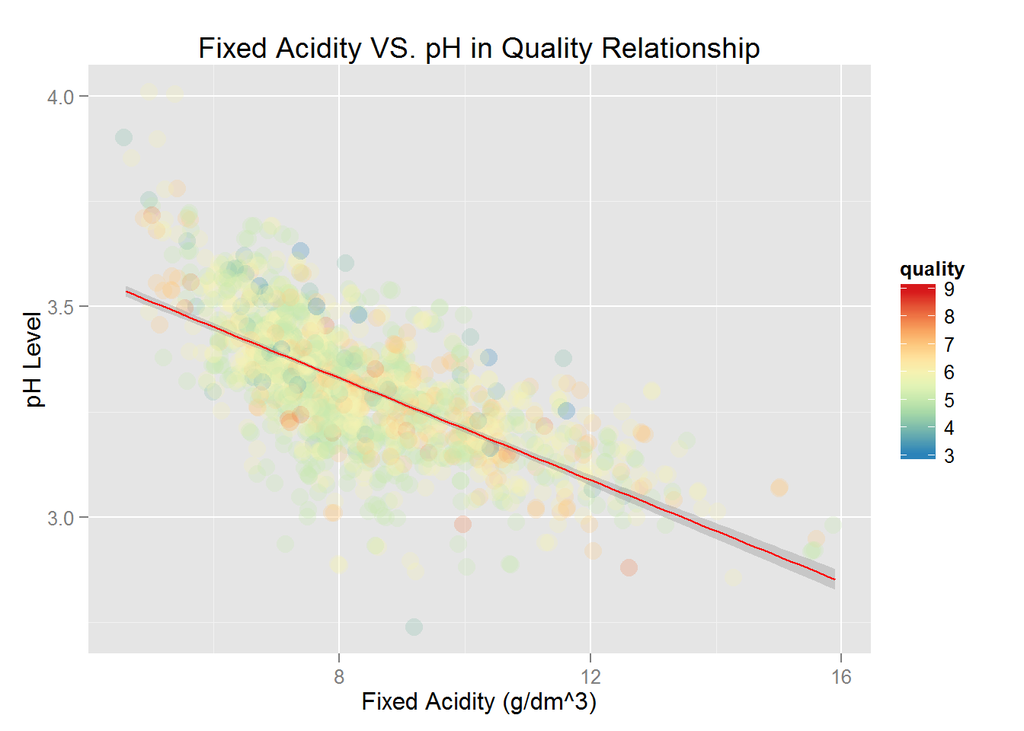

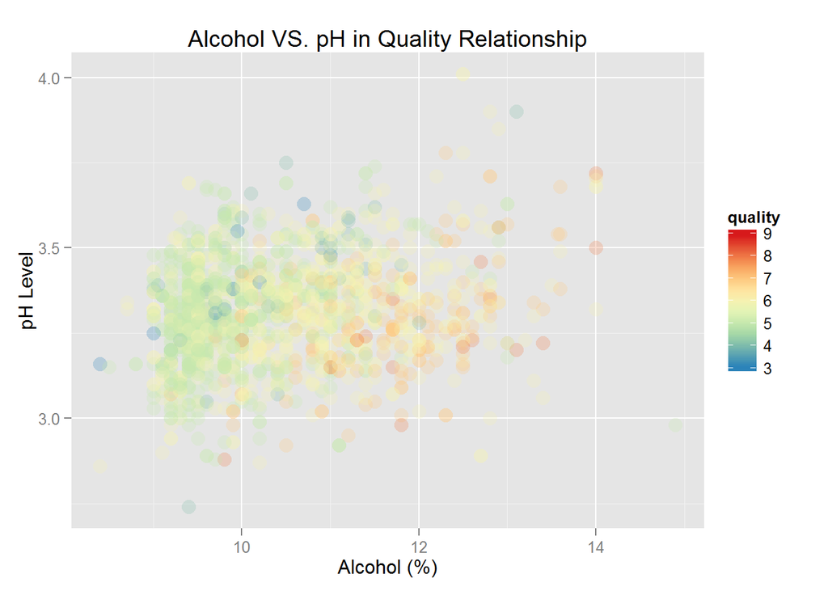

- In this plot, we do not see a strong correlation between alcohol and pH level given the correlation value of only .206. We choose to create this plot because we want to see how low correlation would look like in a plot. We can also see that pH level does not seem to have a big impact on the quality of red wine with correlation value of -.058.

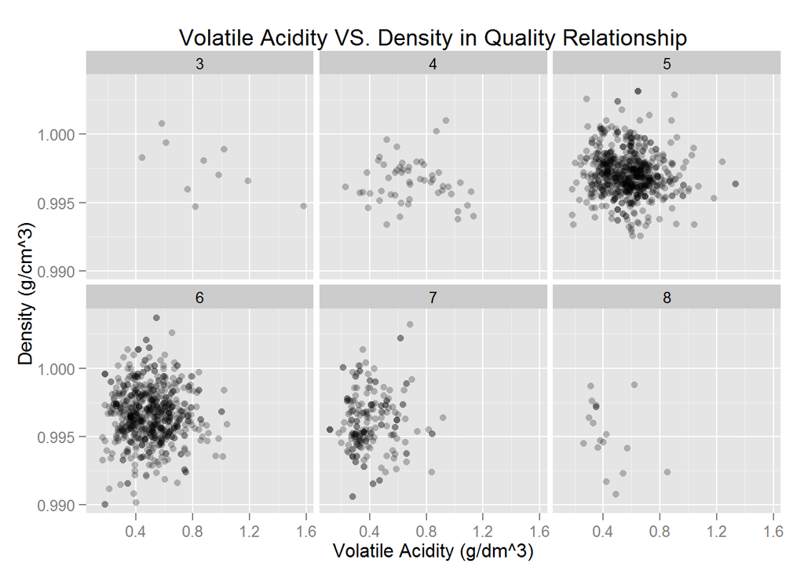

- In this plot, we do not see much correlation between volatile acidity and density as the correlation value is only .022. We created this plot to observe the correlation between density and quality as wine drinker myself prefer a thicker (less dense) wine. We do see a slight correlation between density and quality. As we can see that density decrease, the quality should slightly increases with correlation value of -.175.

# Final Plots

### Red Wine Quality Distribition plot

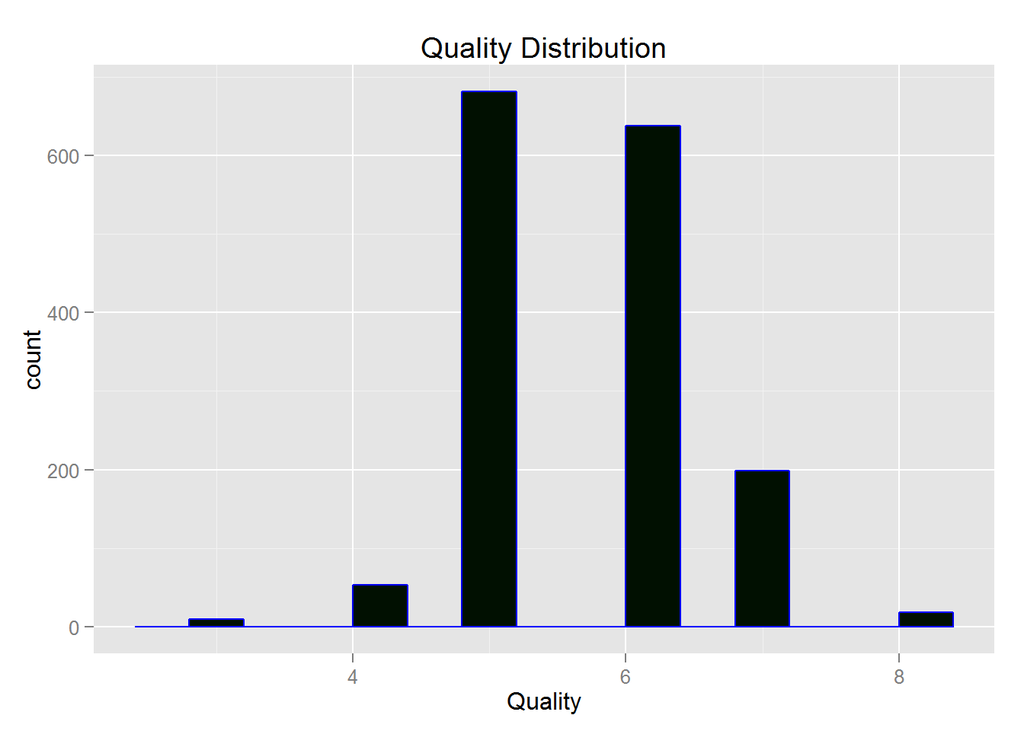

- The red wine distribution plot confirms the quality distribution previously that most red wine are between 4 to 7 with 5 and 6 being the most popular.

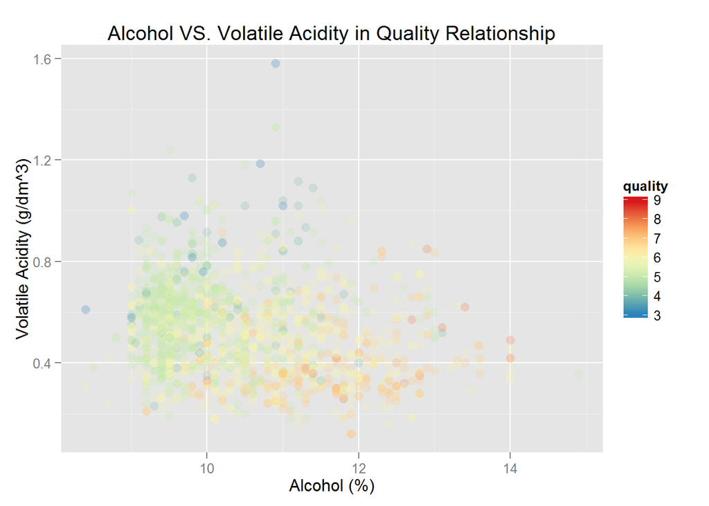

- In this plot, we can see that red wine with quality of 3 has relatively high volatile acidity and low alcohol level. As the quality improves, the data moves towards lower volatile acidity and higher alcohol level. We do not see a strong relationship between alcohol and volatile acidity.

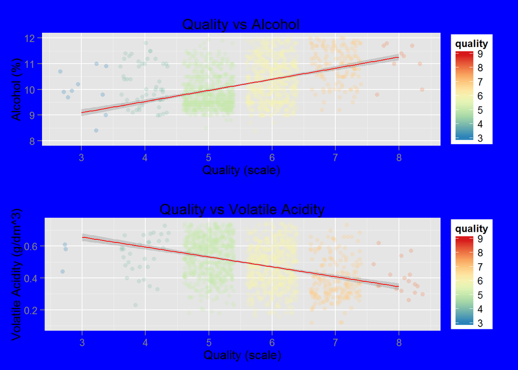

- The two above plots show the direct and inverse relationships between Quality vs Alcohol and Quality vs Volatile Acidity. Although we see a correlation between these input variables with quality, but the correlation is not strong enough to build a prediction model for wine quality.

# Reflection

The red wine data-set contains 1599 with 11 input chemical variables and 1 output quality ranking variable. I started by understanding the individual variables in the data set, and then I further explored interesting observation using various types of plots including histograms, scatter-plot matrices, and ggpair plots. In my exploration, I found many struggles such as making the plots viewable and easy to understand. For example, the ggpair plot has overlapping labels because there are too many variables in the plot. I resolved it by breaking down to three individual ggpair plots that compare with the output variable ‘quality’. Using the ggpair plot, we can see that most input variables do not have a direct strong correlation with quality, but alcohol level is one variable with a strong positive correlation to the quality ranking, and volatile acidity one variable with a strong negative correlation. In my next exploration, I found that pH does not have a strong correlation with alcohol and quality, but density does has a slight correlation with quality.

Given that some this data-set quality ranking came from only 3 wine experts, I am not very convinced that we can draw into conclusion that increasing alcohol or decreasing volatile acidity will give wine better quality ranking. The standards of performance that wine experts use to judge wine quality include balance, length, depth, complexity, finish, and typicity. The details of each of the quality variables can be found in (http://www.dummies.com/how-to/content/how-to-discern-wine-quality.html). To further enhance and improve the analysis, I believe the wine experts should include this information when they are giving the quality ranking to this data-set.